# Kids Have Skills?

# Setup

- 2 schools
- 1 class per school
- 94 kids

## In theory, we have data

- Surveys
- Peer Surveys
- Cooperation
- Fixed vs Growth Mindset
- EEG's on concentration tasks
- Network

# Is that really a thing?

# History

## Surveys + PCA + Varimax = Personality

- Cristal & Tupes -- 1958
- Warren Norman -- 1963

# Math

### A Factor Model:

$$ \mathbf{X} = \mathbf{F}\mathbf{L'} + \mathbf{E} $$

### Restrictions

$$ \mathbf{cov}(\mathbf{F}) = \mathbf{I} \\ \mathbf{cov}(\mathbf{E}) = \mathbf{\Psi} = diag(\mathbf{\Psi}) $$

### Further restrictions give us PCA

$$ \mathbf{E} \sim N(0, \mathbf{I}) $$

## Solve for Factors:

$$ \mathbf{\hat{F}} = \mathbf{X \Psi^{-1} L(L'\Psi^{-1}L)^{-1}} $$

## With Identity Error Covariance:

$$ \mathbf{\hat{F}} = \mathbf{XL} $$

## Make some rotations

$$ \mathbf{\hat{F}T(LT)'\Psi^{-1}LT} = \mathbf{X\Psi^{-1}LT} \\ \mathbf{\hat{F}TT'L\Psi^{-1}LTT'} = \mathbf{X\Psi^{-1}LTT'} \\ \mathbf{\hat{F}L\Psi^{-1}L} = \mathbf{X\Psi^{-1}L} $$

## Simple Structure = Varimax

$$ \frac{1}{P} \sum_{j=1}^M \bigg( \sum_{i=1}^P\Lambda_{ij}^4 - \bigg( \sum_{i=1}^P\frac{1}{P}\Lambda_{ij}^2\bigg)\bigg) $$

Where $\Lambda$ refers to the normalized loadings. This objective will be most useful to us.

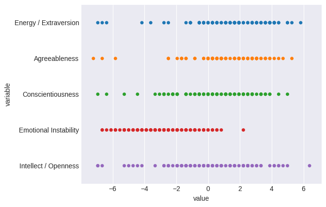

```python
g = sns.stripplot(x = 'value', y = 'variable', data = pd.melt(bigfive), orient = 'h')
```

```python
bf_pca = PCA(5).fit(bf_survey_scaled)
A = bf_pca.components_.T
V,T = rotate_factors(A, 'varimax')
n = np.stack([
        get_exlained_variance(bf_survey_scaled, A.T),
        get_exlained_variance(bf_survey_scaled, V.T),
        get_exlained_variance(bf_survey_scaled, bf_comps.T)]).T

pd.DataFrame(n, columns=["Components", "Varimax", "Big Five"]).T
```

|  | 0 | 1 | 2 | 3 | 4 |
| --- | --- | --- | --- | --- | --- |
| Components | 23.543123 | 7.580135 | 6.321525 | 5.111549 | 3.795437 |
| Varimax | 14.691594 | 5.573418 | 12.284804 | 7.432257 | 6.369697 |
| Big Five | 7.569611 | 7.590264 | 7.664056 | 6.073631 | 8.321417 |

```
Summed variance of first 5 components: 46.3517700504
Summed variance of first 5 components: 46.3517700504
Summed variance of first 5 components: 37.2189799093
```

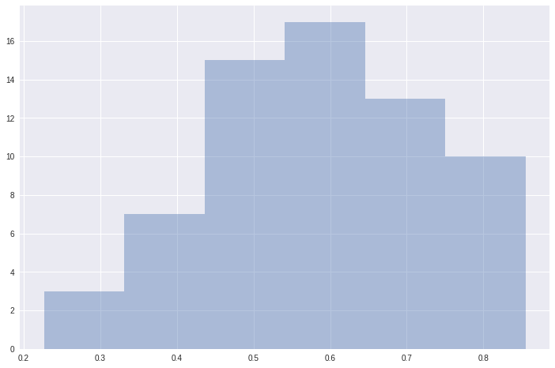

```python
fa = RotatableFA(5).fit(bf_survey_scaled)
F = fa.transform(bf_survey_scaled)
d = sns.distplot(fa.noise_variance_, kde=False)
```

```python
A,FA = rotated_fa(bf_survey_scaled, lambda F: np.eye(F.shape[1]))
V,FV = rotated_fa(bf_survey_scaled, lambda L: rotate_factors(L.T, 'varimax')[1], False)

n = np.stack([
        get_exlained_variance(bf_survey_scaled, A, False),
        get_exlained_variance(bf_survey_scaled, V, False),
        get_exlained_variance(bf_survey_scaled, bf_comps.T)]).T

pd.DataFrame(n, columns=["Components", "Varimax", "Big Five"]).T
```

|  | 0 | 1 | 2 | 3 | 4 |
| --- | --- | --- | --- | --- | --- |
| Components | 22.586949 | 6.474895 | 5.544954 | 4.367940 | 2.922496 |
| Varimax | 13.645560 | 10.342161 | 7.858926 | 4.543434 | 5.507152 |
| Big Five | 7.569611 | 7.590264 | 7.664056 | 6.073631 | 8.321417 |

```
Summed variance of first 5 components: 41.8972335086
Summed variance of first 5 components: 41.8972335086
Summed variance of first 5 components: 37.2189799093
```

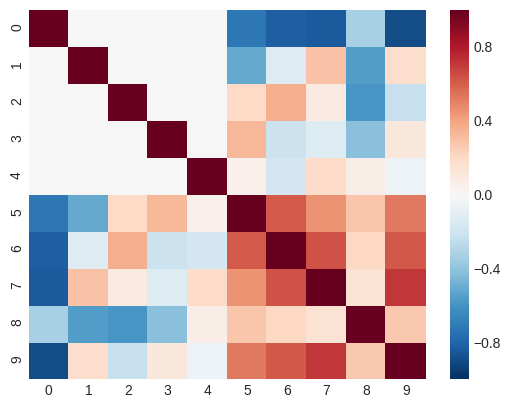

```
                                   0         1         2         3         4
Maximum Factor Correlation  0.331887  0.291065  0.359494  0.332125  0.195156
```

```python
# Basic Factor Analysis on Big Five Survey without rotation
L,F = rotated_fa(bf_survey_scaled, lambda F: np.eye(F.shape[1]))
plot_corr(F, bigfive)
```

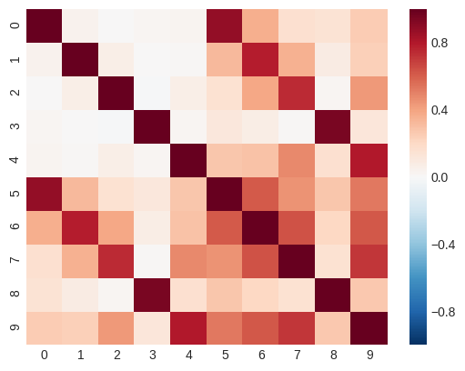

```
                                  0         1         2        3        4
Maximum Factor Correlation  0.88174  0.781647  0.747987  0.95297  0.80298
```

```python
# Factor Analysis with factors rotated to minimize L2 Norm with Big Five
L,F = rotated_fa(bf_survey_scaled, lambda F: target_rotation(F, bigfive))
plot_corr(F, bigfive)
```

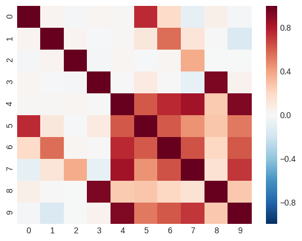

```
                                   0        1         2        3         4
Maximum Factor Correlation  0.748137  0.55708  0.369989  0.93869  0.932587
```

```python
# Factor Analysis with factors rotated in order to maximize Varimax objective
# in the correlation matrix with the bigfive factors.
L,F = rotated_fa(bf_survey_scaled, lambda F: varimax_gpa(F, bigfive))
plot_corr(F, bigfive)
```

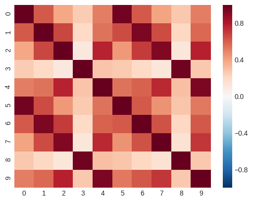

```
                                   0         1         2         3         4
Maximum Factor Correlation  0.968546  0.943092  0.922326  0.973424  0.942151
```

```python
L,F = rotated_fa(bf_survey_scaled, lambda F: varimax_gpa(F, bigfive, 'oblique'))
plot_corr(F, bigfive)
```

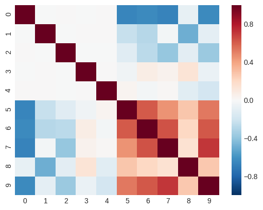

```
                                   0         1         2         3         4
Maximum Factor Correlation  0.083879  0.025884  0.107176  0.134254  0.031207
```

```python
L,F = rotated_fa(others_scaled, lambda F: np.eye(F.shape[1]))
plot_corr(F, bigfive)
```

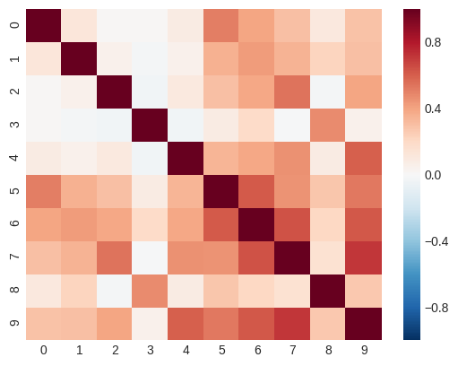

```
                                   0         1        2         3         4
Maximum Factor Correlation  0.512753  0.423017  0.54649  0.469321  0.600568
```

```python
L,F = rotated_fa(others_scaled, lambda F: target_rotation(F, bigfive))
plot_corr(F, bigfive)
```

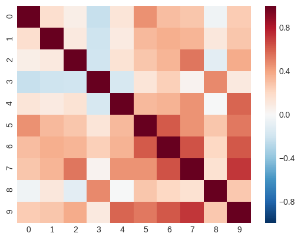

```
                                  0         1         2         3         4
Maximum Factor Correlation  0.45928  0.364635  0.534948  0.481461  0.580808
```

```python
def norm(A=None, T=None, L=None):
    L = A.dot(T) if L is None else L
    return np.linalg.norm(L - bigfive, 1)

L,F = rotated_fa(others_scaled, lambda F: varimax_gpa(F, bigfive, 'oblique', norm))
plot_corr(F, bigfive)
```

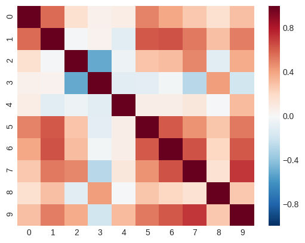

```
                                   0         1         2        3         4
Maximum Factor Correlation  0.493596  0.639058  0.489409  0.42177  0.312784
```

```python
L,F = rotated_fa(others_scaled, lambda F: varimax_gpa(F, bigfive, 'oblique'))
plot_corr(F, bigfive)
```

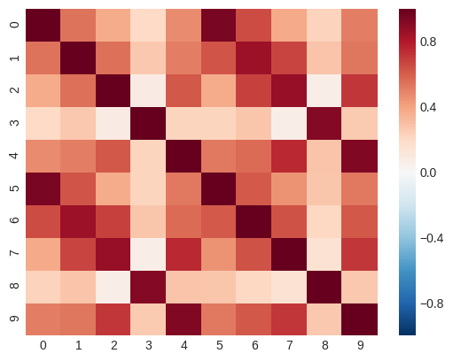

```
                                   0         1         2         3         4
Maximum Factor Correlation  0.948249  0.858054  0.874393  0.915086  0.923285
Summed variance of first 5 components: 41.7923318685
```

```python
T = target_rotation(plssvd.x_scores_, bigfive)
F = rotate(plssvd.x_scores_, T)
plot_corr(F, bigfive)
max_corr(F, bigfive)
g = get_exlained_variance(bf_survey, plssvd.x_weights_.T)
```

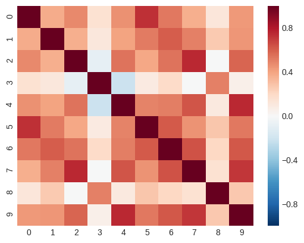

```
                                   0        1         2         3         4
Maximum Factor Correlation  0.726848  0.60881  0.753055  0.506655  0.750198
Summed variance of first 5 components: 41.1344585457
```

```python
T = target_rotation(plssvd.y_scores_, bigfive)
F = rotate(plssvd.y_scores_, T)
plot_corr(F, bigfive)
g = get_exlained_variance(others, plssvd.y_weights_.T)
```

# Regression

## Goals

- The Big Five personality traits are alive and well in our population, and measurable through our data-collection techniques.
- One or more of these traits will exist as important latent factors in every measurement we use to predict noncognitive skills of students.
- For each measurement, the exact number or identification of exhibited traits is not determined ahead-of-time, but there will be prior beliefs.
- Relax Gaussianity.
- Relax the linear relationship between latent factors and observed variables.

# Playtime

# Elastic Net

$$ \DeclareMathOperator*{\argmin}{argmin} \hat{\beta} = argmin_{\beta}||y - \mathbf{X}\beta ||^2 + \lambda_2|| \beta ||^2 + \lambda_1 || \beta ||_1 $$

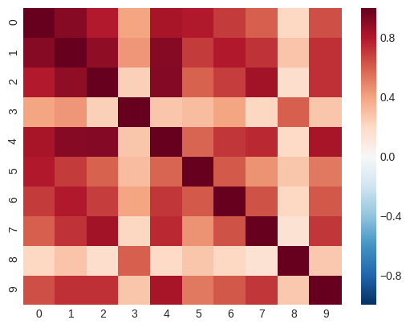

[output not shown]

```python
enet = MultiElasticNet(alpha = 0.4, l1_ratio = .5)
fitted = enet.fit(others, bigfive.as_matrix())
L = np.array(enet.coef_).T
plot_corr(others_scaled.dot(L), bigfive)
g = get_exlained_variance(others, enet.coef_)
```

# Concerns

> By no means is there any indication of a large general factor, for instance, one attributable to general evaluative tendencies or social desirability, present anywhere in these results... It is thus reassuring to this writer at least, to observe that no factor was found which even closely resembled such a general evaluative response set effect in any of these analyses. --Warren T. Norman

# Wrap Up

- Five factors seem to exist
- Inspiration for prediction